# scRNAseq exercise

27-Nov-2025

Yuan Li (yuan.li@nbis.se)

```r
library(Seurat)
library(ggplot2) # plotting
library(patchwork) # combining figures
library(dplyr)
library(scater)
```

# 1 Import data

```r
data.filt = readRDS("../results/data.filt.RDS")
data.filt
```

```
## An object of class Seurat
## 26818 features across 1014 samples within 2 assays
## Active assay: SCT (13016 features, 2000 variable features)
##  3 layers present: counts, data, scale.data
##  1 other assay present: RNA
##  1 dimensional reduction calculated: pca
```

# 2 Run SCTranform again and regress out more unwanted covariates

But first we need to identify the main unwanted variates

For this, we will run PCA first

Top PCs will catch major variation in the data

We can then build a linear model to calculate the percentage of variation that each top PC are explained by different covariates.

```
## [1] "Plot contribution of metadata to each PCs..."
```

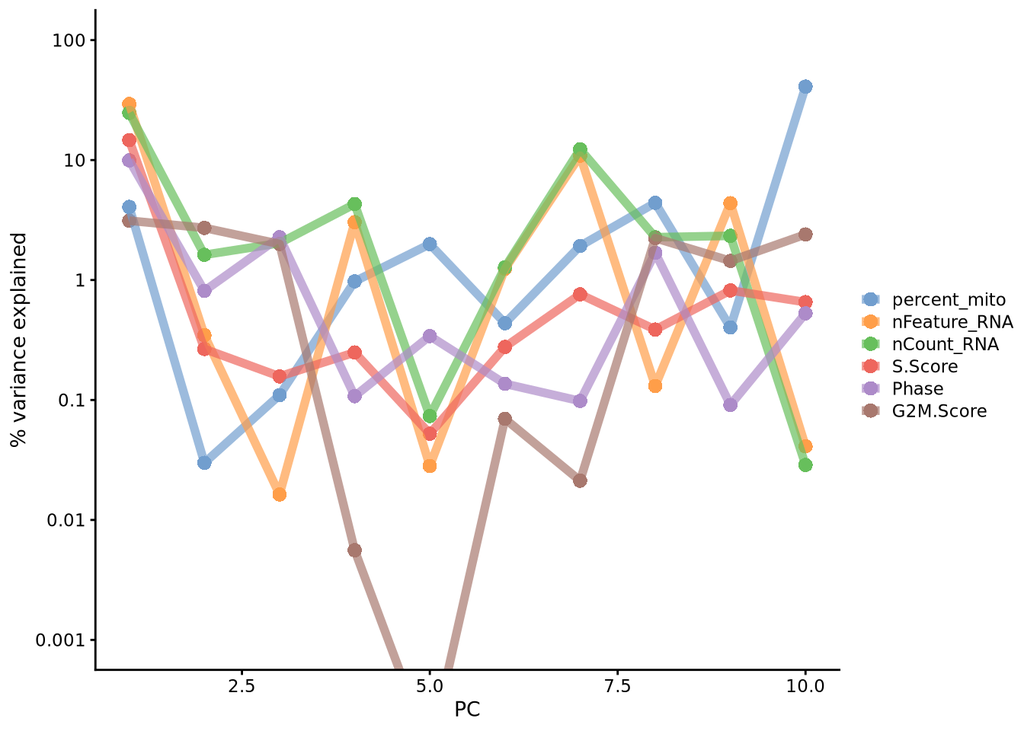

```r
DefaultAssay(data.filt) = "SCT"

data.filt = RunPCA(data.filt, npcs = 100, verbose = F, assay = "SCT")
# Plot contribution of metadata to each PCs (variation explained by each metadata)
print("Plot contribution of metadata to each PCs...")
dummy = SingleCellExperiment::SingleCellExperiment(
  list(pc_space=t(data.filt@reductions$pca@cell.embeddings[, 1:10])),
  colData=data.filt@meta.data[, c("nCount_RNA", "nFeature_RNA", "percent_mito",
                                  "S.Score", "G2M.Score", "Phase")])
explan_pcs = scater::getVarianceExplained(dummy, exprs_values="pc_space")
# pdf("explain_pcs.pdf")
scater::plotExplanatoryPCs(explan_pcs)
# dev.off()
```

From the plot above, we can see that, four shown meta.data (nFeature_RNA, nCount_RNA, S.Score, Phase) explain more than 10% of the variation in the top PC, we may regress them out duing `SCTransform`

- nCount_RNA (i.e. total cell UMI count) are in the NB GLM model by default, so no need to add again, nFeature_RNA is highly positively correlated with nCount_RNA, we shouldn’t add it either
  - The reason that nCount_RNA and nFeature_RNA still explain a big portion of the data variation is because SCTransform only removes the technical component of the total cell UMI count/seq depth,
  - the biological component of sequencing depth still remains (e.g. seq depth may differ between different cell types…)
- We already know from last tutorial Phase is not accurate, so we will regres out S.Score only. Though sometimes, one may want to keep the cell cycle info in the data.
- If you want to, you can regress out percent.mit as well, it is often correlated with cell quality.

Let’s run `SCTransform` and regress out S.Score at the same time

```r
# Let's check the counts data before regressing
data.filt[["SCT"]]$counts[1:10, 1:20]

data.filt = SCTransform(data.filt, assay = "RNA",
                        new.assay.name = "SCT",
                        variable.features.n = 2000,
                        do.scale=F, do.center = F,
                        return.only.var.genes = F,
                        vars.to.regress = c("S.Score"))

# Let's check the counts slot again
data.filt[["SCT"]]$counts[1:10, 1:20]
# Do they differ now?
```

```
## 10 x 20 sparse Matrix of class "dgCMatrix"
##
## AL669831.5 . . . . . . . . . . . . 1 . . 1 . . . .
## LINC00115  . . . 1 . . . . . . . . . . . . . . . .
## FAM41C     . . . . . . . 1 . . . . . . . 1 . . . .
## NOC2L      . . . 1 1 . 1 1 . . . . 1 . . . 1 . . .
## KLHL17     . . . . . . . . . . . . . . . . . . . .
## PLEKHN1    . . . . . . . . . . . . . . . . . . . .
## HES4       . . . . . . . 1 . . . . . . . . . . . .
## ISG15      . . 3 . . . . . . . . . 1 1 . . . . . .
## AGRN       . . . . . . . . . . . . . . . . . . . .
## C1orf159   . . . . . . . . . . . . . . . . . . . .
## 10 x 20 sparse Matrix of class "dgCMatrix"
##
## AL669831.5 . . . . . . . . . . . . 1 . . 1 . . . .
## LINC00115  . . . 1 . . . . . . . . . . . . . . . .
## FAM41C     . . . . . . . 1 . . . . . . . 1 . . . .
## NOC2L      . . . 1 1 . 1 1 . . . . 1 . . . 1 . . .
## KLHL17     . . . . . . . . . . . . . . . . . . . .
## PLEKHN1    . . . . . . . . . . . . . . . . . . . .
## HES4       . . . . . . . 1 . . . . . . . . . . . .
## ISG15      . . 3 . . . . . . . . . 1 1 . . . . . .
## AGRN       . . . . . . . . . . . . . . . . . . . .
## C1orf159   . . . . . . . . . . . . . . . . . . . .
```

# 3 Dimensional Reduction

## 3.1 PCA

Let’s have a closer look at the PCA analysis

Principlal component analysis (PCA) reduces the number of dimensions in large datasets to a few number of principal componnets that retain most of the original informaton.

PCA aims to maximize the data variation explained by the PCs.

The first principal component is formed as a linear combination of the original variables/genes (each with a loading value) that explains the most variance.

The second principal component explains the most variance in what is left once the effect of the first component is removed, and we may proceed through iterations until all the variance is explained.

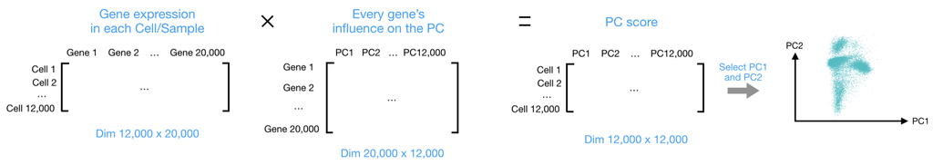

Let’s run PCA:

```r
data.filt = RunPCA(data.filt, npcs = 100, verbose = F, assay = "SCT")
```

It is mostly those top PCs that contain useful information, the rest of the PCs (principal components) may mostly contain random noises.

In Seurat, the tSNE and UMAP analyses below are based on the PCA result, we will only select the top significant PCs and feed them to tSNE and UMAP.

**How do we select the right number of top PCs?**

A common method for determining the number of PCs to be retained is a graphical representation known as an elbow plot.

An **elbow plot** is a simple line segment plot that shows the data variation explained by each PC.

- It shows the variation explained by each PC on the y-axis and the number of PCs on the x-axis.
- It always displays a downward curve. Most elbow plots look broadly similar in shape, starting high on the left, falling rather quickly, and then flattening out at some point.
- This is because the first component usually explains much of the variability, the next few components explain a moderate amount, and the latter components only explain a small fraction of the overall variability.
- The elbow plot criterion looks for the “elbow” in the curve and selects all components just before the line flattens out.

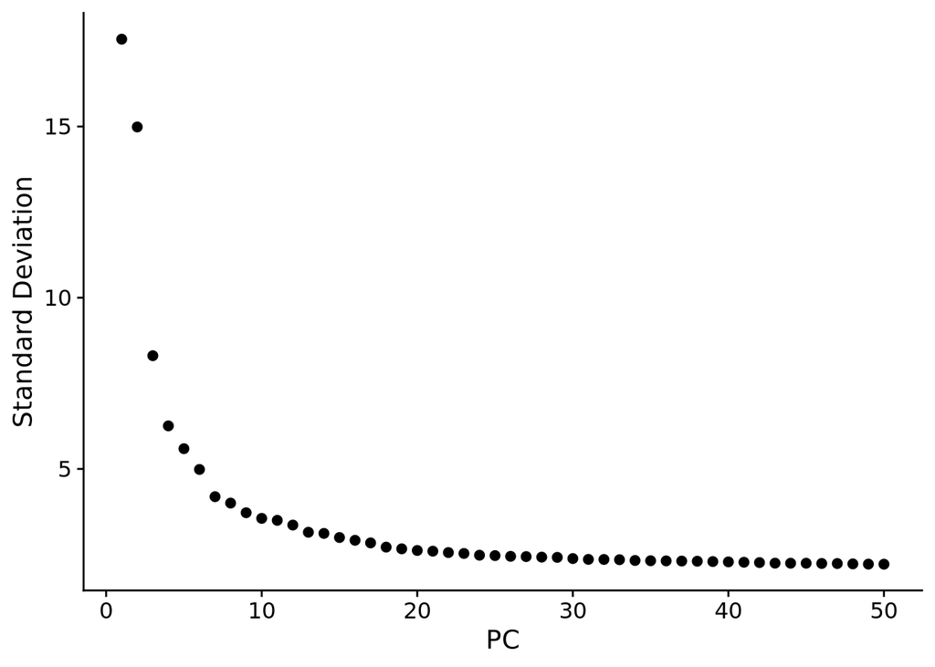

```r
ElbowPlot(data.filt, reduction = "pca", ndims = 50)
```

Here, 10 looks a good number to keep, but we usually keep a bit more than that to make sure we get most of the useful information, Let’s keep 15 instead.

## 3.2 tSNE

```r
data.filt = RunTSNE(
    data.filt,
    reduction = "pca", dims = 1:15, # Here we tell RunTSNE to use top 15 PCs
    perplexity = 30, # low perplexity: finer structure
    max_iter = 1000,
    theta = 0.5,
    eta = 200,
    num_threads = 0
)

# run ?RunTSNE to see how to adjust parameters.
```

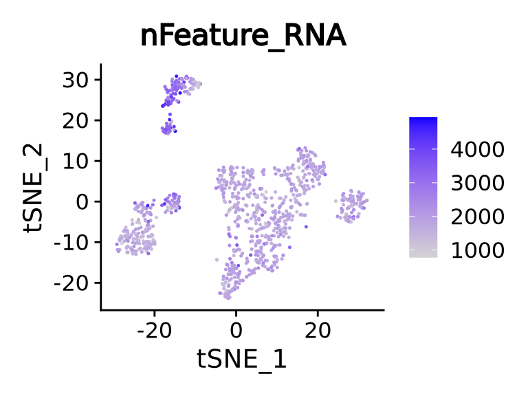

```r
FeaturePlot(data.filt, reduction = "tsne",
            features = "nFeature_RNA", pt.size=0.1)
# run ?DimPlot to see how to adjust parameters.
```

What does each dot represent in the sSNE plot?

## 3.3 UMAP

```r
data.filt = RunUMAP(
    data.filt,
    reduction = "pca",
    dims = 1:15, # Here we tell RunUMAPE to use top 15 PCs
    n.components = 2,
    n.neighbors = 30,
    n.epochs = 200,
    min.dist = 0.3,
    learning.rate = 1,
    spread = 1
)

# Run ?RunUMAP to see how to adjust the parameters
# n.neighbors: Larger values will result in more global structure being preserved at the loss of detailed local structure.
## In general this parameter should often be in the range 5 to 50.
# min_dist: The minimum distance between two points in the UMAP embedding.
# spread: A scaling factor for distance between embedded points.
```

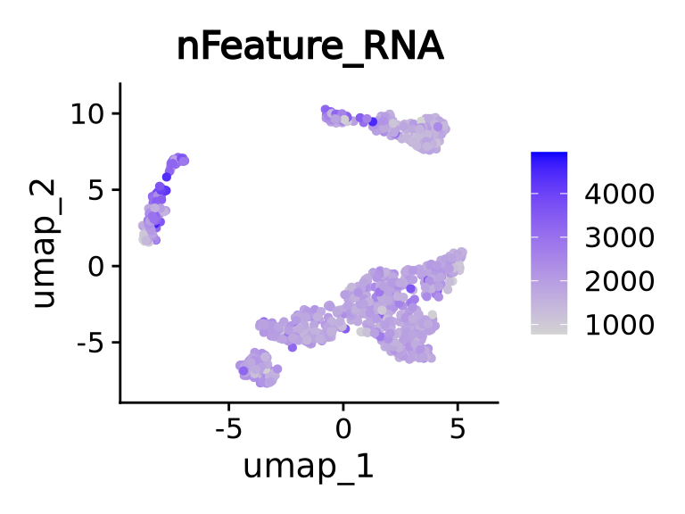

```r
FeaturePlot(data.filt, reduction = "umap", features = "nFeature_RNA")
```

How different is it between a tSNE plot and a UMAP plot?

Let’s plot all three dimensional reduciton plots together

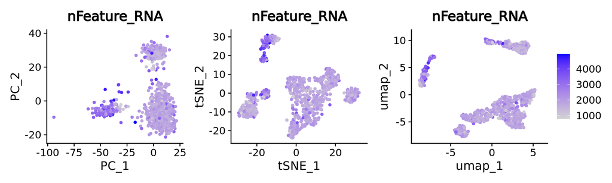

```r
wrap_plots(
    FeaturePlot(data.filt, reduction = "pca", features = "nFeature_RNA"),
    FeaturePlot(data.filt, reduction = "tsne", features = "nFeature_RNA"),
    FeaturePlot(data.filt, reduction = "umap", features = "nFeature_RNA"),
    ncol = 3
) + plot_layout(guides = "collect")
```

# 4 Cell-level automatic annotation

For demonstration, here, we will only use one automatic annotation method (cell-based, reference-based), called label transfer (from Seurat).

It needs three functions, `FindTransferAnchors()`, `TransferData()` and `AddMetaData()`.

From the `FindTransferAnchors()` function, we will use `pcaproject`, ie the query dataset is projected onto the PCA of the reference dataset.

Then the labels of cells in the query dataset will be decided based on the labels of its reference neighbors in the PCA space.

First, download the reference data

```r
reference = readRDS("../data/reference.RDS")
```

Let’s process the reference data set as well,

we will run all the steps that we did for our dataset in one go with the pipe-operator `%>%`.

```r
reference = reference %>%
    SCTransform() %>%
    RunPCA(verbose = F) %>%
    RunUMAP(dims = 1:15)
```

Then we do label transfer:

```r
transfer.anchors = FindTransferAnchors(
    reference = reference, query = data.filt,
    dims = 1:15, reduction = "pcaproject")

predictions = TransferData(
    anchorset = transfer.anchors, refdata = reference$cell_type,
    dims = 1:15
)

data.filt = AddMetaData(object = data.filt, metadata = predictions)
```

**Confidence of label transfering**

We can then examine the distribution of the prediction scores and optionally filter out those cells with low scores.

Here, we find that most cells receive a score of 0.8 or greater.

```
##
## FALSE  TRUE
##   165   849
```

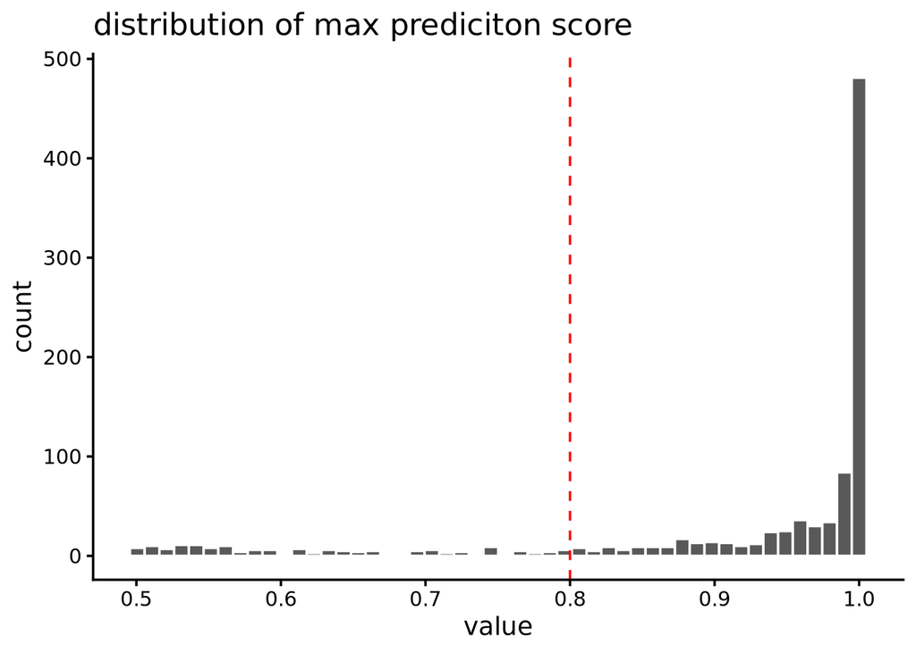

```r
data.filt@meta.data$prediction.score.max %>%
  tibble::enframe() %>%
  ggplot(aes(x=value)) +
  geom_histogram(color = "white", bins = 50) +
  geom_vline(xintercept = 0.8, linetype = 2, color = "red") +
  theme_classic(base_size = 14) +
  ggtitle("distribution of max prediciton score")

# Let's see how many cells have prediction scores > 0.8:
table(data.filt@meta.data$prediction.score.max>0.8)

# Let's only keep cell labels that have prediction scores > 0.8:
data.filt@meta.data$predicted.id[!data.filt@meta.data$prediction.score.max>0.8] = "NA"
```

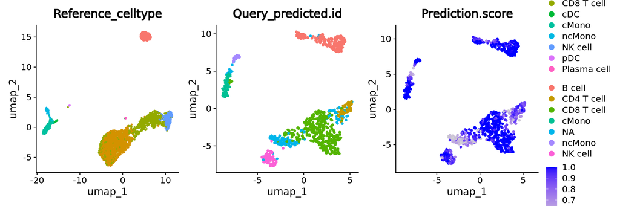

```r
# pdf("Test1.pdf", h=4, w=12)
wrap_plots(
    DimPlot(reference, reduction="umap", group.by="cell_type") + ggtitle("Reference_celltype"),
    DimPlot(data.filt, reduction="umap", group.by="predicted.id") + ggtitle("Query_predicted.id"),
    FeaturePlot(data.filt, reduction="umap", features="prediction.score.max") + ggtitle("Prediction.score"),
    ncol = 3
) + plot_layout(guides = "collect")
# dev.off()
```

- For the three figures above, the one to the left is the reference dataset,
- the one in the middle is the predicted lables in the query dataset,
- while the one to the right shows the confidence scores of the predicted labels in the query dataset.

**We can now use this prediction result to help us choose the right clustering resolution**

- cMono: classical monocyte, i.e. CD14+ monocyte
- ncMono: non-classical monocyte.

For other automatic annotation methods, please see my lectures.

# 5 Clustering

```r
# First we need to build a SNN Graph
data.filt = FindNeighbors(data.filt,
    reduction = "pca",
    assay = "RNA",
    k.param = 20,
    features = VariableFeatures(data.filt)
)

# SNN was built based on pca.
# run ?FindNeighbors to see how to adjust the parameters

# Clustering with few different clustering resolutions
#library(leiden)
for (res in c(0.1, 0.3, .5, 1, 1.5, 2, 2.5, 3, 3.5)) {
    data.filt = FindClusters(data.filt, graph.name = "SCT_snn",
                             resolution = res, algorithm = 2)
}
# Algorithm for modularity optimization (
# 1 = original Louvain algorithm;
# 2 = Louvain algorithm with multilevel refinement;
# 3 = SLM algorithm;
# 4 = Leiden algorithm). Leiden requires the leidenalg python.

# ?FindClusters
```

```
## Modularity Optimizer version 1.3.0 by Ludo Waltman and Nees Jan van Eck
##
## Number of nodes: 1014
## Number of edges: 30679
##
## Running Louvain algorithm with multilevel refinement...
## Maximum modularity in 10 random starts: 0.9545
## Number of communities: 5
## Elapsed time: 0 seconds
## Modularity Optimizer version 1.3.0 by Ludo Waltman and Nees Jan van Eck
##
## Number of nodes: 1014
## Number of edges: 30679
##
## Running Louvain algorithm with multilevel refinement...
## Maximum modularity in 10 random starts: 0.9045
## Number of communities: 7
## Elapsed time: 0 seconds
## Modularity Optimizer version 1.3.0 by Ludo Waltman and Nees Jan van Eck
##
## Number of nodes: 1014
## Number of edges: 30679
##
## Running Louvain algorithm with multilevel refinement...
## Maximum modularity in 10 random starts: 0.8722
## Number of communities: 9
## Elapsed time: 0 seconds
## Modularity Optimizer version 1.3.0 by Ludo Waltman and Nees Jan van Eck
##
## Number of nodes: 1014
## Number of edges: 30679
##
## Running Louvain algorithm with multilevel refinement...
## Maximum modularity in 10 random starts: 0.8066
## Number of communities: 9
## Elapsed time: 0 seconds
## Modularity Optimizer version 1.3.0 by Ludo Waltman and Nees Jan van Eck
##
## Number of nodes: 1014
## Number of edges: 30679
```

[output cut: 26 more lines]

```
## Number of edges: 30679
##
## Running Louvain algorithm with multilevel refinement...
## Maximum modularity in 10 random starts: 0.6212
## Number of communities: 15
## Elapsed time: 0 seconds
## Modularity Optimizer version 1.3.0 by Ludo Waltman and Nees Jan van Eck
##
## Number of nodes: 1014
## Number of edges: 30679
##
## Running Louvain algorithm with multilevel refinement...
## Maximum modularity in 10 random starts: 0.5874
## Number of communities: 18
## Elapsed time: 0 seconds
```

Each time you run clustering, the data is stored in meta data columns:

```r
data.filt@meta.data[1:5, ]
# Can you see columns for the clustering results with different resolutions?
```

|  | orig.ident | nCount_RNA | nFeature_RNA | percent_mito | outlier_mt | outlier_nCount_RNA | Outlier_combined | nCount_SCT | nFeature_SCT | S.Score | G2M.Score | Phase | pANN_0.25_0.05_8 | doublet_finder | predicted.id | prediction.score.CD8.T.cell | prediction.score.CD4.T.cell | prediction.score.cMono | prediction.score.B.cell | prediction.score.NK.cell | prediction.score.pDC | prediction.score.ncMono | prediction.score.cDC | prediction.score.Plasma.cell | prediction.score.max | SCT_snn_res.0.1 | seurat_clusters | SCT_snn_res.0.3 | SCT_snn_res.0.5 | … |
| --- | --- | --- | --- | --- | --- | --- | --- | --- | --- | --- | --- | --- | --- | --- | --- | --- | --- | --- | --- | --- | --- | --- | --- | --- | --- | --- | --- | --- | --- | --- |
| AGGTCTAGTAGCTTAC-5 | ctrl_5 | 4289 | 1526 | 7.131205 | FALSE | FALSE | FALSE | 5289 | 1518 | -0.01349907 | -0.03210310 | G1 | 0.17647059 | Singlet | NA | 0.5342251 | 0 | 0 | 0.0000000 | 0.4657749 | 0 | 0 | 0.00000000 | 0 | 0.5342251 | 0 | 12 | 2 | 3 | … |
| TCAGGGCTCTCCCTAG-5 | ctrl_5 | 5775 | 1781 | 6.608997 | FALSE | FALSE | FALSE | 5765 | 1772 | -0.01938977 | 0.04872255 | G2M | 0.26470588 | Singlet | CD8 T cell | 1.0000000 | 0 | 0 | 0.0000000 | 0.0000000 | 0 | 0 | 0.00000000 | 0 | 1.0000000 | 0 | 1 | 0 | 0 | … |
| AATCGTGTCATTCGGA-5 | ctrl_5 | 15455 | 3036 | 9.014485 | FALSE | FALSE | FALSE | 6074 | 1784 | -0.00663433 | 0.01625122 | G2M | 0.10294118 | Singlet | B cell | 0.0000000 | 0 | 0 | 0.9690877 | 0.0000000 | 0 | 0 | 0.03091232 | 0 | 0.9690877 | 1 | 10 | 1 | 7 | … |
| GGTCACGCATTACGGT-5 | ctrl_5 | 5062 | 1660 | 8.764311 | FALSE | FALSE | FALSE | 5449 | 1645 | -0.02703287 | -0.03780575 | G1 | 0.01470588 | Singlet | B cell | 0.0000000 | 0 | 0 | 0.9879103 | 0.0000000 | 0 | 0 | 0.01208970 | 0 | 0.9879103 | 1 | 2 | 1 | 2 | … |
| TCGCTCAGTAAGTCAA-5 | ctrl_5 | 5145 | 1793 | 7.926948 | FALSE | FALSE | FALSE | 5478 | 1787 | 0.10777067 | -0.03810926 | S | 0.07352941 | Singlet | NA | 0.4768981 | 0 | 0 | 0.0000000 | 0.5231019 | 0 | 0 | 0.00000000 | 0 | 0.5231019 | 0 | 8 | 2 | 3 | … |

- seurat_clusters - lastest results only
- SCT_snn_res.XX - for each different resolution you test.

Plot the clustering results:

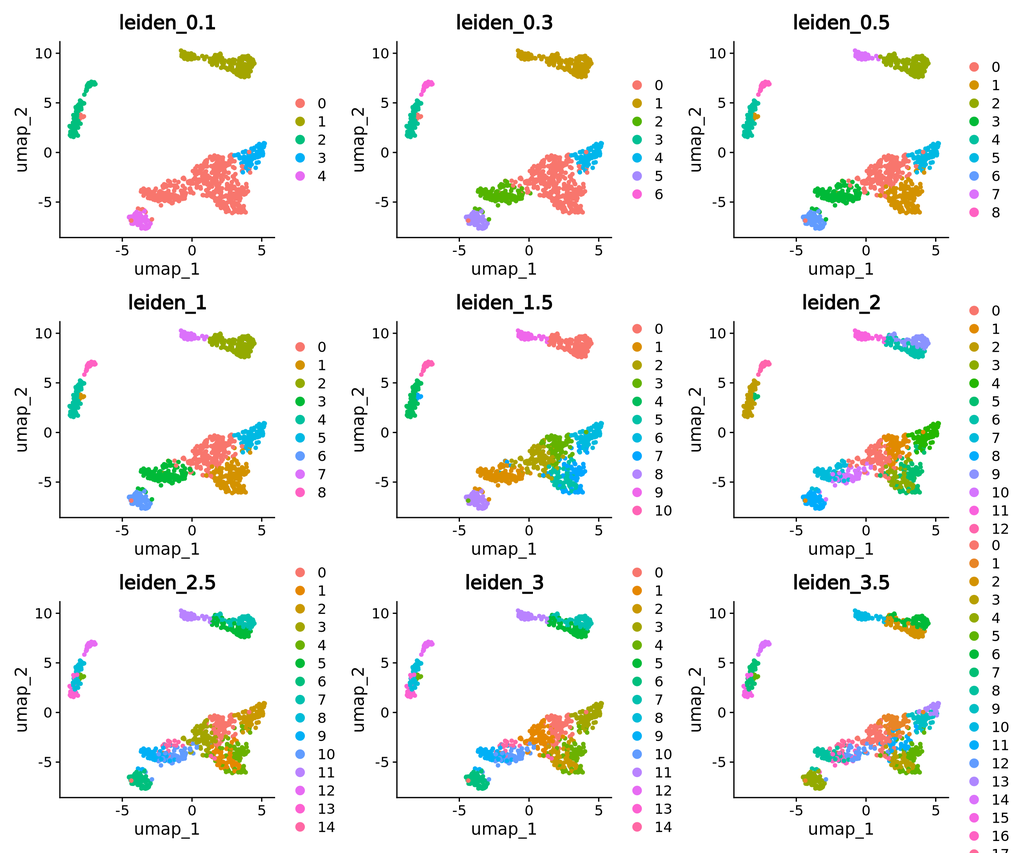

```r
# pdf("Test.pdf", h=10, w=12)
wrap_plots(
    DimPlot(data.filt, reduction = "umap", group.by = "SCT_snn_res.0.1") +
      ggtitle("leiden_0.1"),
    DimPlot(data.filt, reduction = "umap", group.by = "SCT_snn_res.0.3") +
      ggtitle("leiden_0.3"),
    DimPlot(data.filt, reduction = "umap", group.by = "SCT_snn_res.0.5") +
      ggtitle("leiden_0.5"),
    DimPlot(data.filt, reduction = "umap", group.by = "SCT_snn_res.1") +
      ggtitle("leiden_1"),
    DimPlot(data.filt, reduction = "umap", group.by = "SCT_snn_res.1.5") +
      ggtitle("leiden_1.5"),
    DimPlot(data.filt, reduction = "umap", group.by = "SCT_snn_res.2") +
      ggtitle("leiden_2"),
    DimPlot(data.filt, reduction = "umap", group.by = "SCT_snn_res.2.5") +
      ggtitle("leiden_2.5"),
    DimPlot(data.filt, reduction = "umap", group.by = "SCT_snn_res.3") +
      ggtitle("leiden_3"),
    DimPlot(data.filt, reduction = "umap", group.by = "SCT_snn_res.3.5") +
      ggtitle("leiden_3.5"),
    ncol = 3
)
# dev.off()
```

Which clustering resolution give a result that agrees with our cell-level automatic annotation the most?

It seems that resolution 0.3 holds the highest similarity.

Let’s make a stacked barplot to check the correspondence between the predicted.id and the clustering result SCT_snn_res.0.3:

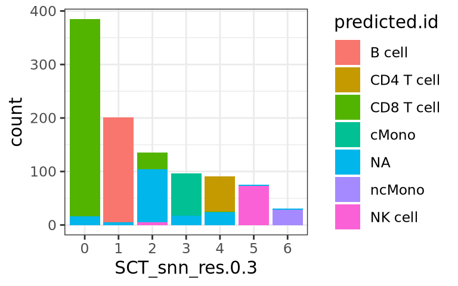

```r
data.filt@meta.data %>%
  ggplot(aes(x=SCT_snn_res.0.3, fill=predicted.id)) +
  geom_bar(stat="count") +
  theme_bw()
```

- Here, the x-axis shows the seven clusters generated at a resolution of 0.3,
- the y-axis represents the number of cells each cluster has,
- while the color of bars represents the corresponding id predicted for each cell by Seurat label transfer automatic annotation.

**The identity of most clusters are rather clear, except cluster 2,**

**for which we may need to gather more information and perform manual annotation.**

But let’s first check whether cluster 2 has any quality issue (e.g. too low nFeature_RNA, nCount_RNA, too high percent_mito …):

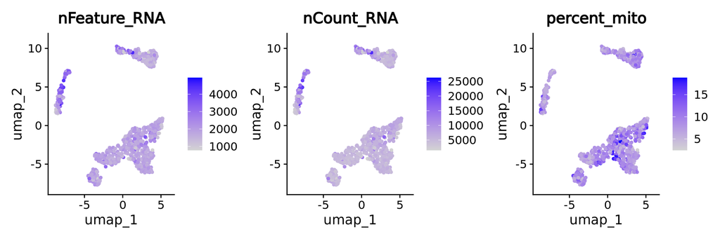

```r
feats = c("nFeature_RNA", "nCount_RNA", "percent_mito")
FeaturePlot(data.filt, features=feats, ncol=3)
```

The quality of cluster 2 looks ok, the nFeature_RNA is not too low and percent_mito is not too high either, nothing is obviously wrong!

Now let’s do some manual annotation to gather more information:

# 6 Manual annotation

**Marker gene table:**

| Markers | Cell Type |
| --- | --- |
| CD3E | T cells |
| CD3E CD4 | CD4+ T cells |
| CD3E CD8A | CD8+ T cells |
| GNLY, NKG7 | NK cells |
| MS4A1 | B cells |
| CD14, LYZ, CST3, MS4A7 | CD14+ Monocytes |
| FCGR3A, LYZ, CST3, MS4A7 | FCGR3A+ Monocytes |
| FCER1A, CST3 | DCs |

Plot the marker genes on the UMAP plot:

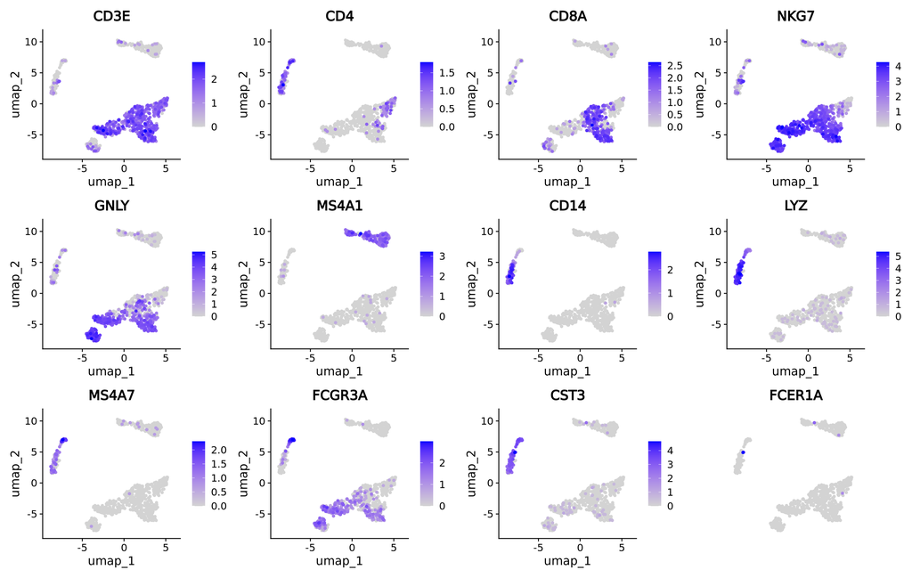

```r
# pdf("Plot3.pdf", h=9.5, w=15)
myfeatures = c("CD3E", "CD4", "CD8A", "NKG7", "GNLY",
  "MS4A1", "CD14", "LYZ", "MS4A7", "FCGR3A", "CST3", "FCER1A")
FeaturePlot(data.filt, reduction = "umap", dims = 1:2,
            features = myfeatures, ncol = 4, order = T) +
            NoLegend() + NoAxes() + NoGrid()
# dev.off()
```

The marker gene expression distribution agree more or less with the cell-level automatic annotation,

But not that helpful when it comes to annotate cluster 2!

Maybe we can do manual annotation from a different angle: explore the differential gene list for each cluster and see what more information we can get there.